# RANGKUMAN MATERI STRUKTUR DATA

Struktur data merupakan cara programmer untuk merepresentasikan suatu data, dan memudahkan programmer untuk menyelesaikan permasalahan dengan menggunakan struktur data tersebut.

Struktur data Linear Structure merupakan struktur data sederhana dimana ketika data ditambahkan maka data tersebut berada pada posisi relatif terhadap data yang lain dari struktur data tersebut. Linear structure ini memiliki dua buah ujung. Dua buah ujung ini memiliki beberapa istilah seperti left-right, front-rear, ataupun top-bottom. Terdapat beberapa struktur data yang termasuk pada linear structure ini, yaitu :

- Stacks
- Queues
- Lists

Ketiga jenis struktur data tersebut berbeda dalam penambahan atau penghapusan suatu data. Misalkan, suatu struktur data hanya diperbolehkan menghapus data pada salah satu ujung,sedangkan pada struktur data lain, penghapusan data dapat dilakukan pada kedua ujung.

# Stack

Stacks adalah satu struktur data dimana penambahan dan penghapusan data, hanya dapat dilakukan pada satu ujung yang sama, atau yang biasa dikenal dengan istilah top.

Semakin data jauh berada dari posisi top, maka data tersebut diindikasikan berada di stack lebih lama dibandingkan dengan data yang berada dekat pada data di posisi top.

Jika terdapat data baru yang ditambahkan di stack, maka data ini pulalah yang akan dihapus ketika terdapat proses penghapusan data. Konsep ini dikenal dengan nama LIFO-Last In First Out.

Contoh: Tumpukan buku

Jika kita ingin mengambil buku pada tumpukan buku tersebut, maka buku yang dapat kita ambil adalah buku yang berada di posisi teratas. Jika ingin mengambil buku yang berada di posisi paling bawah, maka kita harus mengambil buku-buku yang berada di posisi atasnya terlebih dahulu. Begitu juga ketika terdapat penambahan buku baru, maka buku baru ini akan berada di posisi paling atas.

```python
def stack():
    return []

def isEmpty(s):
    return len(s) == 0

def push(s, data):
    s.append(data)

def pop(s):
    if not isEmpty(s):
        return s.pop()

def main():
    data = stack()

    isEmpty(data)

    push(data, 100)
    push(data, 23)
    push(data, 34)

    pop(data)

    push(data, 56)

    pop(data)

    print(data)

main()
```

```
[100, 23]
```

## Operasi pada Stacks

- stack (), inisialisasi stack yang kosong
- push(data), penambahan data baru pada posisi top dari stack
- pop(), penghapusan data yang terdapat di posisi top dari stack. Return value dari fungsi ini adalah data yang dihapus dari stack tersebut
- peek(), informasi data yang terletak pada posisi top
- isEmpty(), untuk memeriksa apakah stack dalam keadaan kosong
- size(), informasi jumlah data yang terdapat pada stack

### Latihan - 1

Buat function untuk 'reverse word' dengan menggunakan konsep stacks, misalkan kata 'stacks' menjadi 'skcats'

```python
def reverseWord(word):
        dataStack=stack()
        for ch in word:
            push(dataStack,ch)
        temp=''
        while not(isEmpty(dataStack)):
            temp=temp+pop(dataStack)
        return temp
print(reverseWord("stacks"))
print(reverseWord("aku"))
```

```
skcats
uka
```

## Implementasi Stacks

Berikut adalah contoh implementasi untuk penggunaan stacks, yaitu delimiter matching dan konversi desimal ke biner

## Delimiter Matching

Parentheses sering digunakan untuk urutan penyelesaian dalam persamaan Matematika, seperti contoh berikut:

P = 5 x (4 + 5) / ((3 + 2) x (10 - 8))

Dengan penggunaan parentheses maka persamaan tersebut dapat diselesaikan secara benar, hanya saja terkadang parentheses yang ditulis tidak lengkap, sehingga hasil persamaan tidak dapat dikerjakan atau tidak sesuai dengan yang diinginkan, seperti contoh berikut :

P = 5 x (4 + 5) / ((3 + 2) x (10 - 8) Oleh karena itu diperlukan algoritma untuk pemeriksaan parentheses ini atau secara umum delimiter, yaitu '{ }', '[ ]', dan '( )'.

Beberapa tahapan atau algoritma untuk pengecekan parentheses ini adalah :

Baca setiap karakter yang terdapat pada suatu string matematika Jika karakter adalah kurung buka, maka masukkan dalam stack Jika karakter adalah kurung tutup, ada beberapa kondisi yang harus diperiksa, yaitu : Jika stack dalam keadaan empty, maka jumlah kurung tutup lebih banyak daripada kurung buku Jika stack dalam keadaan tidak empty, maka maka pop stack, dan cocokkan karakter hasil pop dengan kurung tutup, jika sejenis, maka matched, jika tidak maka jenis kurung tidak sama Jika semua karakter telah terbaca, dan stack masih dalam keadaan terisi (tidak empty), maka jumlah kurung buka lebih banyak daripada kurung tutup

```python
def checkParentheses(strMat):
    data=stack()
    for ch in strMat:
        if ch=='(':
            push(data,ch)
        elif ch==')':
            if isEmpty(data):
                return 'kelebihan kurung tutup'
            else:
                pop(data)
    if isEmpty(data):
        return True
    else:
        return 'Kelebihan kurung buka'
checkParentheses('5 x (4 + 5) / (3 + 2) x (10 - 8))')
```

```
'kelebihan kurung tutup'
```

```python
def checkParentheses(strMat):
    data=stack()
    for ch in strMat:
        if ch=='(':
            push(data,ch)
        elif ch==')':
            if isEmpty(data):
                return 'kelebihan kurung tutup'
            else:
                pop(data)
    if isEmpty(data):
        return True
    else:
        return 'Kelebihan kurung buka'

a='5 x (4 + 5) / (3 + 2) x (10 - 8))'
'300' in a
```

```
False
```

```python
# Berikut adalah fungsi untuk pengecekan kurung pada suatu string matematika
def parenthesesCheck(strMath):
    kurung={')':'(','}':'{',']':'['}
    kurungBuka=kurung.values()
    kurungTutup=kurung.keys()
    temp=stack()
    matched=True
    for ch in strMath:
        if ch in kurungBuka: # if ch in kurung.values()
            push(temp,ch)
        if ch in kurungTutup: #if ch in kurung.keys()
            if isEmpty(temp):
                return 'Kelebihan kurung Tutup'
            else:
                tempKurung=pop(temp)
                if tempKurung==kurung[ch]:
                    matched=matched and True
                else:
                    matched=matched and False
    if not(isEmpty(temp)):
        return 'Kelebihan Kurung Buka'
    if matched==True:
        return 'OK'
    else:
        return 'Tidak Cocok kurungnya'

parenthesesCheck('[5 x (4 + 5)} / (3 + 2) x (10 - 8)')
```

```
'Tidak Cocok kurungnya'
```

```python
def stack():
    return []

def push(s, data):
    s.append(data)

def pop(s):
    return s.pop()

def isEmpty(s):
    return s == []

def size(s):
    return len(s)

def convertBinary(num):
    temp=stack()
    divNum=num
    while divNum>0:
        push(temp,divNum%2)
        divNum=divNum//2
    tempStr=''
    for i in range(size(temp)):
        tempStr=tempStr+str(pop(temp))
    return tempStr

print(convertBinary(25))
```

```
11001
```

```python
def paranthesesCheck(strMath):
    operandStack=stack()
    lenMath=len(strMath)
    openOperand='({['
    closeOperand=')}]'
    #print(lenMath)
    i=0
    Matched=True;
    while i<(lenMath):
        #print(i,'=',strMath[i])
        if strMath[i] in openOperand:
            push(operandStack,strMath[i])
            #print(operandStack)
        elif strMath[i] in closeOperand:
            if not (isEmpty(operandStack)):
                top=pop(operandStack)
                #print("top=",top)
                #print (operandStack)
                if openOperand.index(top)==closeOperand.index(strMath[i]):
                    Matched=Matched and True
                else:
                    Matched=Matched and False
                    print ('Kurung Buka dan Kurang Tutup tidak Cocok')
            else:
                Matched=Matched and False
                print('Jumlah Kurung Tutup lebih banyak')
        i=i+1
        #print(Matched)
    if not(isEmpty(operandStack)):
        Matched=False
        print('Jumlah Kurung Buka Lebih banyak')
    return(Matched)
a='5 x (4 + 5) / ((3 + 2) x (10 - 8)'
isMatched=paranthesesCheck(a)
print(isMatched)
```

```
Jumlah Kurung Buka Lebih banyak
False
```

```python
paranthesesCheck('5 x (4 + 5) / ((3 + 2) x (10 - 8))')
```

```
True
```

```python
paranthesesCheck('5 x (4 + 5} / ((3 + 2) x (10 - 8))')
```

```
Kurung Buka dan Kurang Tutup tidak Cocok
```

```
False
```

### Contoh Soal:

1. Soal

Buat program stack sederhana menggunakan Python dengan operasi:

- push
- pop
- tampilkan isi stack

Tambahkan data:

10, 20, 30

Kemudian hapus 1 data terakhir.

```python
stack = []

# Push
stack.append(10)
stack.append(20)
stack.append(30)

print("Isi stack :", stack)

# Pop
stack.pop()

print("Stack setelah pop :", stack)
```

```
Isi stack : [10, 20, 30]
Stack setelah pop : [10, 20]
```

2. Buat program Stack untuk:
- Menambahkan data "A", "B", "C"
- Menghapus 1 data
- Menampilkan isi stack

```python
stack = []

stack.append("A")
stack.append("B")
stack.append("C")

print("Stack awal :", stack)

stack.pop()

print("Stack setelah pop :", stack)
```

```
Stack awal : ['A', 'B', 'C']
Stack setelah pop : ['A', 'B']
```

# Queue

Rangkuman Queue Pengertian Queue

Queue adalah struktur data yang menggunakan prinsip:

FIFO (First In First Out)

Artinya:

Data yang masuk pertama akan keluar pertama.

Contoh:

- Antrian kasir
- Antrian printer
- Antrian tiket

Operasi pada Queues

Terdapat beberapa operasi dasar pada struktur data Queues ini, antara lain :

- queue (), inisialisasi struktur data queue kosong
- enqueue (data), penambahan *data* baru pada queue
- dequeue (), penghapusan data
- isEmpty(), pengecekan apakah queue dalam keadaan kosong
- size (), informasi jumlah data yang terdapat pada queue
- rear (), melihat angka paling belakang

```python
queue = []

# enqueue
def enqueue(data):
    queue.append(data)
    print(data, "ditambahkan")

# dequeue
def dequeue():
    if len(queue) == 0:
        print("Queue kosong")
    else:
        keluar = queue.pop(0)
        print(keluar, "dihapus")

# front
def front():
    if len(queue) == 0:
        print("Queue kosong")
    else:
        print("Front:", queue[0])

# rear
def rear():
    if len(queue) == 0:
        print("Queue kosong")
    else:
        print("Rear:", queue[-1])

# isEmpty
def isEmpty():
    if len(queue) == 0:
        print("Queue kosong")
    else:
        print("Queue tidak kosong")

# size
def size():
    print("Jumlah data:", len(queue))

# display
def display():
    print("Isi queue:", queue)

# penggunaan
enqueue(10)
enqueue(20)
enqueue(30)

display()

front()

rear()

size()

dequeue()

display()

isEmpty()
```

```
10 ditambahkan
20 ditambahkan
30 ditambahkan
Isi queue: [10, 20, 30]
Front: 10
Rear: 30
Jumlah data: 3
10 dihapus
Isi queue: [20, 30]
Queue tidak kosong
```

```python
def createQueue():
    q=[]
    return (q)
def enqueue(q,data):
    q.insert(0,data)
    return(q)
def dequeue(q):
    data=q.pop()
    return(data)
def isEmpty(q):
    return (q==[])
def size(q):
    return (len(q))
```

```python
def ularNaga(nama, hitungan):
    gameQueue = createQueue()
    for namaAnak in nama:
        enqueue(gameQueue,namaAnak)
    print('Peserta Permainan=',gameQueue)
    while size(gameQueue) > 1:
        for i in range(hitungan):
            enqueue(gameQueue,dequeue(gameQueue))
            print('hitungan ke-',i,'=',gameQueue)
        dequeue(gameQueue)
        print('Peserta Permainan=',gameQueue)
    return dequeue(gameQueue)

ularNaga(['andi','rita','sari','anton','rafa','diana','zaki'],2)
```

```
Peserta Permainan= ['zaki', 'diana', 'rafa', 'anton', 'sari', 'rita', 'andi']
hitungan ke- 0 = ['andi', 'zaki', 'diana', 'rafa', 'anton', 'sari', 'rita']
hitungan ke- 1 = ['rita', 'andi', 'zaki', 'diana', 'rafa', 'anton', 'sari']
Peserta Permainan= ['rita', 'andi', 'zaki', 'diana', 'rafa', 'anton']
hitungan ke- 0 = ['anton', 'rita', 'andi', 'zaki', 'diana', 'rafa']
hitungan ke- 1 = ['rafa', 'anton', 'rita', 'andi', 'zaki', 'diana']
Peserta Permainan= ['rafa', 'anton', 'rita', 'andi', 'zaki']
hitungan ke- 0 = ['zaki', 'rafa', 'anton', 'rita', 'andi']
hitungan ke- 1 = ['andi', 'zaki', 'rafa', 'anton', 'rita']
Peserta Permainan= ['andi', 'zaki', 'rafa', 'anton']
hitungan ke- 0 = ['anton', 'andi', 'zaki', 'rafa']
hitungan ke- 1 = ['rafa', 'anton', 'andi', 'zaki']
Peserta Permainan= ['rafa', 'anton', 'andi']
hitungan ke- 0 = ['andi', 'rafa', 'anton']
hitungan ke- 1 = ['anton', 'andi', 'rafa']
Peserta Permainan= ['anton', 'andi']
hitungan ke- 0 = ['andi', 'anton']
hitungan ke- 1 = ['anton', 'andi']
Peserta Permainan= ['anton']
```

```
'anton'
```

### Contoh Soal :

1. Buat program Queue untuk:
- Menambahkan data 1, 2, 3
- Menghapus data pertama
- Menampilkan queue

```python
queue = []

queue.append(1)
queue.append(2)
queue.append(3)

print("Queue awal :", queue)

queue.pop(0)

print("Queue akhir :", queue)
```

```
Queue awal : [1, 2, 3]
Queue akhir : [2, 3]
```

2. Buat program Queue untuk:
- Menambahkan "Andi", "Budi", "Citra"
- Menghapus satu data
- Menampilkan hasil queue

```python
queue = []

queue.append("Andi")
queue.append("Budi")
queue.append("Citra")

print("Queue awal :", queue)

queue.pop(0)

print("Queue akhir :", queue)
```

```
Queue awal : ['Andi', 'Budi', 'Citra']
Queue akhir : ['Budi', 'Citra']
```

# Ekspressi Aritmatik Infix, Prefix, Postfix

Eksperssi aritmatik yang sering ditemui adalah operasi aritmatik infix. Pada operasi aritmatik infix ini, operator (+,-,*,/, dll) berada diantara dua buah operand (bilangan). Ekspressi aritmatik ini dapat dengan mudah diselesaikan ketika tidak ada ambiguitas, seperti:

A + B A ∗ X A − B + C

Akan tetapi, ekspressi aritmatik ini akan sulit diselesaikan jika terjadi ambiguitas, seperti ekspressi aritmatik berikut ini: A + B ∗ C

Pada ekspressi tersebut, terdapat ambiguitas, yaitu apakah A + B diselesaikan terlebih dahulu ataukah B * C yang harus diselesaikan terlebih dahulu. Ambiguitas ini dapat diatasi dengan konsep operator precedence. Pada operator precedence, operator-operator dibagi menjadi beberapa level berdasarkan prioritas urutan penyelesaian. Pada contoh ekspressi aritmatik A + B * C, berdasarkan operator precedence, maka urutan penyelesaian adalah B * C kemudian hasilnya ditambahkan dengan A. Permasalahan terjadi ketika pada ekspressi aritmatik A + B * C, A + B ingin diselesaikan terlebih dahulu. Untuk penyelesaian ekspressi aritmatik yang tidak sesuai dengan urutan operator precedence, maka tanda '( )' sangatlah diperlukan, sehingga operasi tersebut menjadi (A + B) * C. Tanda '( )' tidaklah diperlukan pada ekspressi aritmatik prefix dan postfix. Pada ekspressi aritmatik prefix, operator mendahului operand, sedangkankan ekspressi aritmatik postfix, operator ditulis setelah operand.

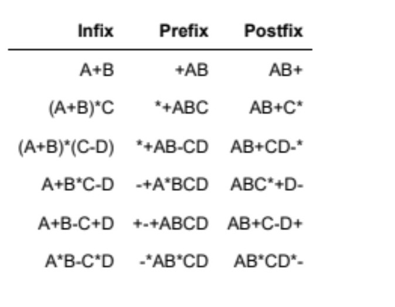

## Konversi Infix ke Postfix

Berikut algoritma untuk konversi ekspressi aritmatik infix ke postfix :

1. Buat struktur data stack untuk menampung operator
2. Baca ekspressi aritmatik dari kiri ke kanan tiap token :

jika token yang dibaca adalah operand maka masukkan operand tersebut ke dalam output string

jika token yang dibaca adalah kurung buka maka push kurung buka tersebut ke dalam stack

jika token yang dibaca adalah kurang tutup maka pop stack semua token sampai ditemukan kurung buka

jika token yang dibaca adalah operator maka :

- pop operator-operator yang memiliki precedence lebih tinggi atau sama dan
- masukkan operator tersebut ke dalam output string
- push token operator ke dalam stack
3. Jika masih terdapat operator pada stack, maka pop operator yang tersisa dan letakkan pada output string

```python
def stack():
    return []
def push(s,data):
    s.append(data)
def pop(s):
    return s.pop()
def isEmpty(s):
    return s==[]
def peek(s):
    return s[-1]
def precedence(op):
    if op == '+' or op == '-':
        return 1
    elif op == '*' or op =='/':
        return 2
    elif op == '^':
        return 3
    else:
        return 0
def infix_to_posfix(expr):
    output=""
    s=stack()
    for ch in expr:
        if ch.isalnum ():
            output+=ch
        elif ch == '(':
            push(s,ch)
        elif ch ==')':
            while not isEmpty(s) and peek (s)!='(':
                output+=pop(s)
                pop(s)
        else:
            while not isEmpty(s) and precedence(peek(s))>=precedence(ch):
                output+=pop(s)
            push(s,ch)
    while not isEmpty(s):
        output+=pop(s)

    return output

expr= '(a-b)*c'
print("Infix", expr)
print("Posfix", infix_to_posfix(expr))
```

```
Infix (a-b)*c
Posfix ab-c*
```

## postfix to infix

```python
def postfix_to_infix(expression):

    stack = []

    for char in expression:

        if char.isalnum():
            stack.append(char)

        else:
            op2 = stack.pop()
            op1 = stack.pop()

            temp = "(" + op1 + char + op2 + ")"

            stack.append(temp)

    return stack[0]

exp = "AB+C*"

print(postfix_to_infix(exp))
```

```
((A+B)*C)
```

## Infix to Prefix

```python
def precedence(op):
    if op in ['+', '-']:
        return 1
    if op in ['*', '/']:
        return 2
    return 0

def infix_to_prefix(expression):
    expression = expression[::-1]

    stack = []
    result = ""

    for char in expression:

        if char.isalnum():
            result += char

        elif char == ')':
            stack.append(char)

        elif char == '(':
            while stack and stack[-1] != ')':
                result += stack.pop()
            stack.pop()

        else:
            while stack and precedence(char) < precedence(stack[-1]):
                result += stack.pop()

            stack.append(char)

    while stack:
        result += stack.pop()

    return result[::-1]

exp = "(A+B)*C"
print(infix_to_prefix(exp))
```

```
*+ABC
```

## prefix to infix

```python
def prefix_to_infix(expression):

    stack = []

    for char in reversed(expression):

        if char.isalnum():
            stack.append(char)

        else:
            op1 = stack.pop()
            op2 = stack.pop()

            temp = "(" + op1 + char + op2 + ")"

            stack.append(temp)

    return stack[0]

exp = "*+ABC"

print(prefix_to_infix(exp))
```

```
((A+B)*C)
```

### Contoh Soal:

1. Ubah ekspresi berikut menjadi postfix:

A + B * C

```python
def stack():
    return []
def push(s,data):
    s.append(data)
def pop(s):
    return s.pop()
def isEmpty(s):
    return s==[]
def peek(s):
    return s[-1]
def precedence(op):
    if op == '+' or op == '-':
        return 1
    elif op == '*' or op =='/':
        return 2
    elif op == '^':
        return 3
    else:
        return 0
def infix_to_posfix(expr):
    output=""
    s=stack()
    for ch in expr:
        if ch.isalnum ():
            output+=ch
        elif ch == '(':
            push(s,ch)
        elif ch ==')':
            while not isEmpty(s) and peek (s)!='(':
                output+=pop(s)
                pop(s)
        else:
            while not isEmpty(s) and precedence(peek(s))>=precedence(ch):
                output+=pop(s)
            push(s,ch)
    while not isEmpty(s):
        output+=pop(s)

    return output

expr= 'a+b*c'
print("Infix", expr)
print("Posfix", infix_to_posfix(expr))
```

```
Infix a+b*c
Posfix abc*+
```

# Sorting

Sorting adalah proses mengurutkan data berdasarkan urutan tertentu, misalnya dari nilai terkecil ke terbesar (ascending) atau terbesar ke terkecil (descending).

### Tujuan sorting:

mempermudah pencarian data membuat data lebih terorganisir meningkatkan efisiensi pengolahan data

Contoh data:

Sebelum sorting

[34, 12, 25, 9, 18]

Setelah sorting (ascending)

[9, 12, 18, 25, 34]

### Beberapa algoritma sorting:

- Bubble Sort
- Selection Sort
- Insertion Sort
- Merge Sort
- Quick Sort
1. Buble Sort

Bubble Sort adalah algoritma pengurutan (sorting) yang bekerja dengan cara membandingkan dua elemen yang berdekatan dalam sebuah daftar, lalu menukarnya jika urutannya salah. Proses ini dilakukan berulang kali sampai seluruh data tersusun dengan benar.

Algoritma ini disebut Bubble Sort karena elemen dengan nilai terbesar (atau terkecil) akan “menggelembung” (bubble) ke posisi akhirnya setelah beberapa kali perbandingan.

Cara Kerja Bubble Sort Bandingkan dua elemen yang bersebelahan. Jika urutannya salah, tukar posisinya. Lanjutkan ke pasangan elemen berikutnya. Setelah satu putaran selesai, elemen terbesar akan berada di posisi terakhir. Ulangi proses hingga tidak ada lagi pertukaran.

Contoh:

- Buble Sort Ascending

```python
lst = [5,0,1,10,7,2,5,4,6,9]
print("Data awal:", lst)

for i in range(len(lst)):
    for j in range(0, len(lst)-i-1):
        if lst[j] > lst[j+1]:
            lst[j], lst[j+1] = lst[j+1], lst[j]

print("Hasil Bubble Sort Ascending:", lst)
```

```
Data awal: [5, 0, 1, 10, 7, 2, 5, 4, 6, 9]
Hasil Bubble Sort Ascending: [0, 1, 2, 4, 5, 5, 6, 7, 9, 10]
```

- Buble Sort Descending

```python
lst = [5,0,1,10,7,2,5,4,6,9]
print("Data awal:", lst)

for i in range(len(lst)):
    for j in range(0, len(lst)-i-1):
        if lst[j] < lst[j+1]:
            lst[j], lst[j+1] = lst[j+1], lst[j]

print("Hasil Bubble Sort Descending:", lst)
```

```
Data awal: [5, 0, 1, 10, 7, 2, 5, 4, 6, 9]
Hasil Bubble Sort Descending: [10, 9, 7, 6, 5, 5, 4, 2, 1, 0]
```

- Manual Ascending Buble Sort

```python
lst = [5,0,1,10,7,2,5,4,6,9]
print("Data awal:", lst)

swap = 0

for k in range(1, len(lst)):
    swapped = False
    print("\nIterasi ke-", k)

    for i in range(0, len(lst)-k):
        if lst[i] > lst[i+1]:
            lst[i], lst[i+1] = lst[i+1], lst[i]
            swap += 1
            swapped = True

        print(lst)

    if not swapped:
        break

print("\nTotal swap:", swap)
print("Hasil akhir (Ascending):", lst)
```

```
Data awal: [5, 0, 1, 10, 7, 2, 5, 4, 6, 9]

Iterasi ke- 1
[0, 5, 1, 10, 7, 2, 5, 4, 6, 9]
[0, 1, 5, 10, 7, 2, 5, 4, 6, 9]
[0, 1, 5, 10, 7, 2, 5, 4, 6, 9]
[0, 1, 5, 7, 10, 2, 5, 4, 6, 9]
[0, 1, 5, 7, 2, 10, 5, 4, 6, 9]
[0, 1, 5, 7, 2, 5, 10, 4, 6, 9]
[0, 1, 5, 7, 2, 5, 4, 10, 6, 9]
[0, 1, 5, 7, 2, 5, 4, 6, 10, 9]
[0, 1, 5, 7, 2, 5, 4, 6, 9, 10]

Iterasi ke- 2
[0, 1, 5, 7, 2, 5, 4, 6, 9, 10]
```

[output cut: 34 more lines]

- Manual Descending Buble Sort

```python
lst = [5,0,1,10,7,2,5,4,6,9]
print("Data awal:", lst)

swap = 0

for k in range(1, len(lst)):
    print("\nIterasi ke-", k)
    swapped = False

    for i in range(0, len(lst)-k):
        if lst[i] < lst[i+1]:
            lst[i], lst[i+1] = lst[i+1], lst[i]
            swap += 1
            swapped = True

        print(lst)

    if not swapped:
        break

print("\nTotal swap:", swap)
print("Hasil akhir (Descending):", lst)
```

```
Data awal: [5, 0, 1, 10, 7, 2, 5, 4, 6, 9]

Iterasi ke- 1
[5, 0, 1, 10, 7, 2, 5, 4, 6, 9]
[5, 1, 0, 10, 7, 2, 5, 4, 6, 9]
[5, 1, 10, 0, 7, 2, 5, 4, 6, 9]
[5, 1, 10, 7, 0, 2, 5, 4, 6, 9]
[5, 1, 10, 7, 2, 0, 5, 4, 6, 9]
[5, 1, 10, 7, 2, 5, 0, 4, 6, 9]
[5, 1, 10, 7, 2, 5, 4, 0, 6, 9]
[5, 1, 10, 7, 2, 5, 4, 6, 0, 9]
[5, 1, 10, 7, 2, 5, 4, 6, 9, 0]

Iterasi ke- 2
[5, 1, 10, 7, 2, 5, 4, 6, 9, 0]
[5, 10, 1, 7, 2, 5, 4, 6, 9, 0]
[5, 10, 7, 1, 2, 5, 4, 6, 9, 0]
[5, 10, 7, 2, 1, 5, 4, 6, 9, 0]
[5, 10, 7, 2, 5, 1, 4, 6, 9, 0]
[5, 10, 7, 2, 5, 4, 1, 6, 9, 0]
[5, 10, 7, 2, 5, 4, 6, 1, 9, 0]
[5, 10, 7, 2, 5, 4, 6, 9, 1, 0]

Iterasi ke- 3
[10, 5, 7, 2, 5, 4, 6, 9, 1, 0]
[10, 7, 5, 2, 5, 4, 6, 9, 1, 0]
[10, 7, 5, 2, 5, 4, 6, 9, 1, 0]
[10, 7, 5, 5, 2, 4, 6, 9, 1, 0]
[10, 7, 5, 5, 4, 2, 6, 9, 1, 0]
[10, 7, 5, 5, 4, 6, 2, 9, 1, 0]
[10, 7, 5, 5, 4, 6, 9, 2, 1, 0]

Iterasi ke- 4
[10, 7, 5, 5, 4, 6, 9, 2, 1, 0]
[10, 7, 5, 5, 4, 6, 9, 2, 1, 0]
[10, 7, 5, 5, 4, 6, 9, 2, 1, 0]
[10, 7, 5, 5, 4, 6, 9, 2, 1, 0]
[10, 7, 5, 5, 6, 4, 9, 2, 1, 0]
[10, 7, 5, 5, 6, 9, 4, 2, 1, 0]

```

[output cut: 12 more lines]

```

Iterasi ke- 7
[10, 7, 6, 9, 5, 5, 4, 2, 1, 0]
[10, 7, 6, 9, 5, 5, 4, 2, 1, 0]
[10, 7, 9, 6, 5, 5, 4, 2, 1, 0]

Iterasi ke- 8
[10, 7, 9, 6, 5, 5, 4, 2, 1, 0]
[10, 9, 7, 6, 5, 5, 4, 2, 1, 0]

Iterasi ke- 9
[10, 9, 7, 6, 5, 5, 4, 2, 1, 0]

Total swap: 29
Hasil akhir (Descending): [10, 9, 7, 6, 5, 5, 4, 2, 1, 0]
```

2. Selection Sort

Selection Sort adalah algoritma pengurutan yang bekerja dengan cara mencari nilai terkecil dari data yang belum terurut, lalu menukarnya dengan posisi pertama pada bagian yang belum terurut.

Cara Kerja

- Cari nilai terkecil dalam daftar.
- Tukar dengan elemen pertama.
- Cari nilai terkecil berikutnya dari sisa data.
- Tukar dengan posisi berikutnya.
- Ulangi sampai semua data terurut.

Contoh Data:

[29, 10, 14, 37, 13]

```python
def selection_sort(data):
    n = len(data)

    for i in range(n):
        min_index = i

        for j in range(i+1, n):
            if data[j] < data[min_index]:
                min_index = j

        data[i], data[min_index] = data[min_index], data[i]

    return data


data = [29, 10, 14, 37, 13]
hasil = selection_sort(data)

print("Data setelah diurutkan:", hasil)
```

```
Data setelah diurutkan: [10, 13, 14, 29, 37]
```

- Selection Sort Ascending

Mengurutkan data dari kecil → besar.

```python
def selection_sort_ascending(data):
    n = len(data)

    for i in range(n):
        min_index = i

        for j in range(i+1, n):
            if data[j] < data[min_index]:
                min_index = j

        data[i], data[min_index] = data[min_index], data[i]

    return data


data = [29, 10, 14, 37, 13]
print("Ascending:", selection_sort_ascending(data))
```

```
Ascending: [10, 13, 14, 29, 37]
```

- Selection Sort Descending

Mengurutkan data dari besar → kecil.

```python
def selection_sort_descending(data):
    n = len(data)

    for i in range(n):
        max_index = i

        for j in range(i+1, n):
            if data[j] > data[max_index]:
                max_index = j

        data[i], data[max_index] = data[max_index], data[i]

    return data


data = [29, 10, 14, 37, 13]
print("Descending:", selection_sort_descending(data))
```

```
Descending: [37, 29, 14, 13, 10]
```

3. Insertion Sort

Insertion Sort adalah algoritma pengurutan yang bekerja dengan cara menyisipkan elemen ke posisi yang tepat pada bagian data yang sudah terurut.

Algoritma ini mirip seperti mengurutkan kartu saat bermain kartu.

Cara Kerja

- Anggap elemen pertama sudah terurut.
- Ambil elemen berikutnya.
- Bandingkan dengan elemen sebelumnya.
- Geser elemen yang lebih besar.
- Masukkan elemen pada posisi yang benar.
- Ulangi sampai semua data terurut.

Contoh:

- Insertion Sort Ascending

```python
def insertion_sort_ascending(data):
    for i in range(1, len(data)):
        key = data[i]
        j = i - 1

        while j >= 0 and key < data[j]:
            data[j + 1] = data[j]
            j -= 1

        data[j + 1] = key

    return data


data = [8, 3, 5, 2]
print("Ascending:", insertion_sort_ascending(data))
```

```
Ascending: [2, 3, 5, 8]
```

- Insertion Sort Descending

```python
def insertion_sort_descending(data):
    for i in range(1, len(data)):
        key = data[i]
        j = i - 1

        while j >= 0 and key > data[j]:
            data[j + 1] = data[j]
            j -= 1

        data[j + 1] = key

    return data


data = [8, 3, 5, 2]
print("Descending:", insertion_sort_descending(data))
```

```
Descending: [8, 5, 3, 2]
```

### Contoh Soal:

1. Buat program Python untuk mengurutkan data berikut secara ascending

[9, 3, 7, 1, 5]

```python
# Data awal
data = [9, 3, 7, 1, 5]

# Menampilkan data awal
print("Data sebelum sorting:")
print(data)

# Proses sorting manual
for i in range(len(data)):
    for j in range(i + 1, len(data)):

        # Tukar jika data lebih besar
        if data[i] > data[j]:
            temp = data[i]
            data[i] = data[j]
            data[j] = temp

# Menampilkan hasil sorting
print("\nData setelah sorting:")
print(data)
```

```
Data sebelum sorting:
[9, 3, 7, 1, 5]

Data setelah sorting:
[1, 3, 5, 7, 9]
```

2. Buat program Python untuk mengurutkan data berikut secara descending [12, 4, 9, 2, 15]

```python
# Data awal
data = [12, 4, 9, 2, 15]

# Menampilkan data awal
print("Data sebelum sorting:")
print(data)

# Proses sorting descending
for i in range(len(data)):
    for j in range(i + 1, len(data)):

        # Tukar jika data lebih kecil
        if data[i] < data[j]:
            temp = data[i]
            data[i] = data[j]
            data[j] = temp

# Menampilkan hasil sorting
print("\nData setelah sorting descending:")
print(data)
```

```
Data sebelum sorting:
[12, 4, 9, 2, 15]

Data setelah sorting descending:
[15, 12, 9, 4, 2]
```

# Searching

Searching adalah proses untuk mencari data tertentu di dalam kumpulan data (array, list, database, dll).

### Jenis-jenis Searching

1. Linear Search (Sequential Search) Metode pencarian dengan mengecek data satu per satu dari awal sampai ketemu.

Ciri-ciri:

- Tidak perlu data terurut
- Sederhana tapi kurang efisien untuk data besar

Algoritma:

- Mulai dari indeks pertama
- Bandingkan dengan target
- Jika sama → ditemukan
- Jika sampai akhir tidak ketemu → tidak ada

Contoh:

```python
def linear_search(data, target):
    for i in range(len(data)):
        if data[i] == target:
            return i
    return -1
data = [10, 25, 7, 30, 18]
hasil = linear_search(data, 30)

print("Ditemukan di index:", hasil)
```

```
Ditemukan di index: 3
```

2. Binary Search

Pencarian cepat pada data yang sudah terurut.

Ciri-ciri:

- Data harus sorted
- Lebih cepat dari linear search

Algoritma:

- Tentukan tengah
- Bandingkan dengan target
- Jika lebih kecil → cari kiri
- Jika lebih besar → cari kanan

Contoh:

```python
def binary_search(data, target):
    kiri = 0
    kanan = len(data) - 1

    while kiri <= kanan:
        tengah = (kiri + kanan) // 2

        if data[tengah] == target:
            return tengah
        elif data[tengah] < target:
            kiri = tengah + 1
        else:
            kanan = tengah - 1

    return -1

data = [2, 4, 6, 8, 10, 12, 14]
hasil = binary_search(data, 10)

print("Ditemukan di index:", hasil)
```

```
Ditemukan di index: 4
```

```python
def unorderedSequential(arr,cari):
  ind=0
  found=False
  while ind<len(arr) and  not found:
    if cari == arr[ind]:
      found=True
    else:
      ind=ind+1
  return found
arr=[3,6,2,7,4,12,40]
unorderedSequential(arr,2)
```

```
True
```

```python
def orderedSequential(arr,cari):
  ind=0
  found=False
  stop=False
  while ind<len(arr) and  not found and not stop:
    if cari == arr[ind]:
      found=True
    else:
      if arr [ind] > cari:
        stop=True
      else:
        ind=ind+1
  return found
arr=[3,6,7,9,12,15,70]
orderedSequential(arr,9)
```

```
True
```

```python
def binarysearch(arr,cari):
  first = 0
  last = len(arr)-1
  found = False
  while first <= last and not found:
    midpoint= (first+last)//2
    if arr [midpoint]==cari:
      found=True
    else:
      if cari < arr[midpoint]:
        last=midpoint-1
      else:
        first=midpoint+1
  return found
arr=[3,6,7,9,12,15,70]
binarysearch(arr,3)
```

```
True
```

```python
def linearSearch(arr,cari):
  idx=[]
  i=0
  found=False
  while i<len(arr):
    if arr[i]==cari:
      idx.append(i)
      found=True
    i=i+1
  if found==True:
    return idx
  else:
    return "Data Tidak di temukan"


arr=[12,5,9,8,1,10,26,5,9,5]
linearSearch(arr,5)
```

```
[1, 7, 9]
```

```python
def binarysearch(arr,target,awal,akhir):
  if awal>akhir:
    print("data tidak ditemukan")
  else:
    mid=(awal+akhir)//2
    print(f"Check index ke:{mid}")
    if arr[mid]==target:
      print(f"Data ditemukan pada index: {mid}")
    elif target>arr[mid]:
      binarysearch(arr,target,mid+1,akhir)
    elif target<arr[mid]:
      binarysearch(arr,target,awal,mid-1)

arr=[20,32,35,40,56,70]
binarysearch(arr,56,0,len(arr)-1)
```

```
Check index ke:2
Check index ke:4
Data ditemukan pada index: 4
```

### Contoh Soal:

1. Buat program:
- Jika data tidak terurut → sequential search
- Jika data terurut → binary search

Program harus: Mengecek apakah data terurut dan Menggunakan algoritma yang sesuai untuk melakukan pencarian data

Data: [12, 5, 9, 8, 1, 10, 26]

Key yang dicari: 10

Status Data: Tidak Terurut

Algoritma yang digunakan: Sequential Search

Hasil: Data ditemukan pada index ke-5

Jumlah iterasi: 6

```python
def cek_urut(arr):
  for i in range (len(arr)-1):
    if arr[i]>arr[i+1]:
      return False
  return True

def seq_search(arr,key):
  iterasi=0
  for i in range (len(arr)):
    iterasi += 1
    if arr[i]==key:
      return i, iterasi
  return -1, iterasi

def binary_search(arr, key):
    first = 0
    last = len(arr) - 1
    iterasi = 0

    while first <= last:
        iterasi += 1
        mid = (first + last) // 2
        if arr[mid] == key:
            return mid, iterasi
        elif key < arr[mid]:
            last = mid - 1
        else:
            first = mid + 1
    return -1, iterasi

arr = [12, 5, 9, 8, 1, 10, 26]
key = 10

print("Data:", arr)
print("Key yang dicari:", key)

if cek_urut(arr):
    print("Status Data: Terurut")
    print("Algoritma yang digunakan: Binary Search")

    index, iterasi = binary_search(arr, key)

else:
    print("Status Data: Tidak Terurut")
    print("Algoritma yang digunakan: Sequential Search")

    index, iterasi = seq_search(arr, key)

if index != -1:
    print(f"Data ditemukan pada index ke-{index}")
else:
    print("Data tidak ditemukan")

print("Jumlah iterasi:", iterasi)
```

```
Data: [12, 5, 9, 8, 1, 10, 26]
Key yang dicari: 10
Status Data: Tidak Terurut
Algoritma yang digunakan: Sequential Search
Data ditemukan pada index ke-5
Jumlah iterasi: 6
```

# Hashing

Hashing adalah teknik menyimpan dan mencari data dengan menggunakan fungsi hash untuk menghasilkan alamat/index tertentu.

Contoh Fungsi Hash Sederhana

Misalnya:

h(x) = x mod 10

Data: 27, 45, 12, 33

- 27 mod 10 = 7
- 45 mod 10 = 5
- 12 mod 10 = 2
- 33 mod 10 = 3

| Index | Data |
| --- | --- |
| 2 | 12 |
| 3 | 33 |
| 5 | 45 |
| 7 | 27 |

### Collison

Collision terjadi ketika 2 data masuk ke index hash yang sama.

Contoh:

h(15) = 15 mod 7 = 1 h(22) = 22 mod 7 = 1 (tabrakan)

Contoh Kode:

```python
# ukuran hash table
size = 7

# membuat hash table kosong
table = [[] for _ in range(size)]

# fungsi hash
def hash_function(key):
    return key % size

# fungsi insert
def insert(key):
    index = hash_function(key)
    table[index].append(key)

# fungsi search
def search(key):
    index = hash_function(key)

    if key in table[index]:
        return index

    return -1

# data
data = [15, 22, 9, 28]

# memasukkan data
for d in data:
    insert(d)

# menampilkan hash table
print(table)

# mencari data
print("Cari 22 di index:", search(22))
```

```
[[28], [15, 22], [9], [], [], [], []]
Cari 22 di index: 1
```

### COLLISION HANDLING DALAM HASHING

1. CHAINING (Separate Chaining) Konsep

Setiap index di hash table menyimpan list (linked list).

Jika terjadi collision → data ditambahkan ke list di index tersebut ([15, 22, 29]).

Contoh:

```python
# ukuran hash table
size = 7

# membuat table kosong
table = [[] for _ in range(size)]

# fungsi hash
def hash_function(key):
    return key % size

# insert data
def insert(key):
    index = hash_function(key)
    table[index].append(key)

# search data
def search(key):
    index = hash_function(key)

    if key in table[index]:
        return index
    else:
        return -1

# data
data = [15, 22, 29]

# memasukkan data
for d in data:
    insert(d)

# tampilkan table
print(table)

# mencari data
print("22 ditemukan di index:", search(22))
```

```
[[], [15, 22, 29], [], [], [], [], []]
22 ditemukan di index: 1
```

2. OPEN ADDRESSING

Jika terjadi collision, data tidak disimpan di list, tapi dicari slot kosong lain dalam tabel.

Jenis Open Addressing:

- LINEAR PROBING

Jika index sudah penuh → geser ke index berikutnya satu per satu.

Contoh:

```python
size = 7
table = [None] * size

# fungsi hash
def hash_function(key):
    return key % size

# insert
def insert(key):
    index = hash_function(key)

    while table[index] is not None:
        index = (index + 1) % size

    table[index] = key

# search
def search(key):
    index = hash_function(key)
    start = index

    while table[index] is not None:
        if table[index] == key:
            return index

        index = (index + 1) % size

        if index == start:
            break

    return -1

# data
data = [15, 22, 29]

for d in data:
    insert(d)

print(table)

print("22 ditemukan di index:", search(22))
```

```
[None, 15, 22, 29, None, None, None]
22 ditemukan di index: 2
```

- QUADRATIC PROBING Jika collision terjadi → loncat dengan jarak kuadrat

Contoh:

```python
size = 7
table = [None] * size

# hash function
def hash_function(key):
    return key % size

# insert
def insert(key):
    index = hash_function(key)
    i = 0

    while table[(index + i*i) % size] is not None:
        i += 1

    new_index = (index + i*i) % size
    table[new_index] = key

# search
def search(key):
    index = hash_function(key)
    i = 0

    while table[(index + i*i) % size] is not None:
        new_index = (index + i*i) % size

        if table[new_index] == key:
            return new_index

        i += 1

        if i == size:
            break

    return -1

# data
data = [15, 22, 29]

for d in data:
    insert(d)

print(table)

print("22 ditemukan di index:", search(22))
```

```
[None, 15, 22, None, None, 29, None]
22 ditemukan di index: 2
```

3. Mid Square Method (Hash Function)

Mid Square Method adalah metode hashing dengan cara:

- Mengkuadratkan key/data
- Mengambil beberapa digit tengah hasil kuadrat
- Digit tengah digunakan sebagai index hash

Metode ini digunakan agar distribusi data lebih merata.

Contoh;

```python
# fungsi mid square hash
def mid_square_hash(key):
    # kuadratkan key
    square = key * key

    # ubah ke string
    square_str = str(square)

    # cari tengah
    mid = len(square_str) // 2

    # ambil 1 digit tengah
    hash_value = int(square_str[mid])

    return hash_value

# contoh data
data = [25, 12, 36, 47]

# proses hashing
for d in data:
    print("Key:", d, "Hash:", mid_square_hash(d))
```

```
Key: 25 Hash: 2
Key: 12 Hash: 4
Key: 36 Hash: 9
Key: 47 Hash: 0
```

### Contoh Soal :

```python
def remainderFunction(data, modulo):
    return data % modulo

def createHashTable(size):
    return [[None] for i in range(size)]

def chaining(data, hashTable):
    modulo = len(hashTable)

    for item in data:
        slot = remainderFunction(item, modulo)

        if hashTable[slot][0] == None:
            hashTable[slot][0] = item
        else:
            hashTable[slot].append(item)

    return hashTable

a = [54, 26, 93, 17, 77, 31, 44, 55, 20]

hashTable = createHashTable(11)
hashTable = chaining(a, hashTable)
print(hashTable)
```

```
[[77, 44, 55], [None], [None], [None], [26], [93], [17], [None], [None], [31, 20], [54]]
```

# Merge Sort

Merge Sort adalah algoritma pengurutan yang menggunakan metode:

Divide and Conquer

Artinya:

- Data dibagi menjadi bagian kecil -Setiap bagian diurutkan
- Digabung kembali menjadi data terurut
- Konsep Dasar Merge Sort

Merge Sort bekerja dengan cara:

- Membagi array menjadi dua bagian
- Membagi lagi sampai tersisa 1 elemen
- Menggabungkan kembali secara terurut

Langkah-Langkah Merge Sort

1. Divide

Membagi array menjadi dua bagian.

2. Conquer

Mengurutkan bagian kecil secara rekursif.

3. Combine

Menggabungkan array menjadi urut.

Contoh Merge Sort

Data:

[8, 4, 2, 6]

Pembagian

[8, 4] [2, 6]

[8] [4] [2] [6]

Penggabungan

[8] [4] → [4, 8]

[2] [6] → [2, 6]

Hasil Akhir

[2, 4, 6, 8]

```python
def merge_sort(data):

    if len(data) > 1:

        # mencari tengah
        mid = len(data) // 2

        # membagi array
        left = data[:mid]
        right = data[mid:]

        # rekursif
        merge_sort(left)
        merge_sort(right)

        i = 0
        j = 0
        k = 0

        # menggabungkan data
        while i < len(left) and j < len(right):

            if left[i] < right[j]:
                data[k] = left[i]
                i += 1
            else:
                data[k] = right[j]
                j += 1

            k += 1

        # sisa elemen kiri
        while i < len(left):
            data[k] = left[i]
            i += 1
            k += 1

        # sisa elemen kanan
        while j < len(right):
            data[k] = right[j]
            j += 1
            k += 1


# data
data = [38, 27, 43, 3, 9, 82, 10]

print("Sebelum:", data)

merge_sort(data)

print("Sesudah:", data)
```

```
Sebelum: [38, 27, 43, 3, 9, 82, 10]
Sesudah: [3, 9, 10, 27, 38, 43, 82]
```

```python
def merge_sort(a_list):
    print("Splitting ", a_list)
    if len(a_list) > 1:
        mid = len(a_list) // 2
        left_half = a_list[:mid]
        right_half = a_list[mid:]
        merge_sort(left_half)
        merge_sort(right_half)
        i = 0 #indeks left half
        j = 0 #indeks right half
        k = 0 # indeks hasil merging/sorting
        while i < len(left_half) and j < len(right_half):
            if left_half[i] < right_half[j]:
                a_list[k] = left_half[i]
                i = i + 1
            else:
                a_list[k] = right_half[j]
                j = j + 1
                k = k + 1
        while i < len(left_half):
            a_list[k] = left_half[i]
            i = i + 1
            k = k + 1
        while j < len(right_half):
            a_list[k] = right_half[j]
            j = j + 1
            k = k + 1
    print("Merging ", a_list)

a = [38,12,65,22,78,25,83,21,90]
merge_sort(a)
```

```
Splitting  [38, 12, 65, 22, 78, 25, 83, 21, 90]
Splitting  [38, 12, 65, 22]
Splitting  [38, 12]
Splitting  [38]
Merging  [38]
Splitting  [12]
Merging  [12]
Merging  [12, 38]
Splitting  [65, 22]
Splitting  [65]
Merging  [65]
Splitting  [22]
Merging  [22]
Merging  [22, 65]
Merging  [22, 65, 65, 22]
Splitting  [78, 25, 83, 21, 90]
Splitting  [78, 25]
Splitting  [78]
Merging  [78]
Splitting  [25]
Merging  [25]
Merging  [25, 78]
Splitting  [83, 21, 90]
Splitting  [83]
Merging  [83]
Splitting  [21, 90]
Splitting  [21]
Merging  [21]
Splitting  [90]
Merging  [90]
Merging  [90, 90]
Merging  [90, 90, 90]
Merging  [90, 90, 90, 21, 90]
Merging  [90, 90, 90, 21, 90, 25, 83, 21, 90]
```

### Contoh Soal

Perhatikan program Merge Sort berikut.

Modifikasilah program agar dapat mengurutkan data secara descending.

```python
def merge_sort(arr):

    if len(arr) > 1:

        mid = len(arr) // 2

        left = arr[:mid]
        right = arr[mid:]

        merge_sort(left)
        merge_sort(right)

        i = j = k = 0

        while i < len(left) and j < len(right):

            if left[i] < right[j]:
                arr[k] = left[i]
                i += 1

            else:
                arr[k] = right[j]
                j += 1

            k += 1

        while i < len(left):
            arr[k] = left[i]
            i += 1
            k += 1

        while j < len(right):
            arr[k] = right[j]
            j += 1
            k += 1


data = [8, 3, 5, 1, 9]

merge_sort(data)

print(data)
```

```
[1, 3, 5, 8, 9]
```

```python
# jawaban

def merge_sort(arr):

    if len(arr) > 1:

        mid = len(arr) // 2

        left = arr[:mid]
        right = arr[mid:]

        merge_sort(left)
        merge_sort(right)

        i = j = k = 0

        while i < len(left) and j < len(right):

            # Diubah menjadi >
            if left[i] > right[j]:
                arr[k] = left[i]
                i += 1

            else:
                arr[k] = right[j]
                j += 1

            k += 1

        while i < len(left):
            arr[k] = left[i]
            i += 1
            k += 1

        while j < len(right):
            arr[k] = right[j]
            j += 1
            k += 1


data = [8, 3, 5, 1, 9]

merge_sort(data)

print("Hasil sorting descending:")
print(data)
```

```
Hasil sorting descending:
[9, 8, 5, 3, 1]
```

# Quick Sort

Quick Sort adalah algoritma pengurutan yang menggunakan metode:

Divide and Conquer

Quick Sort bekerja dengan cara memilih sebuah pivot

Membagi data:

- lebih kecil dari pivot
- lebih besar dari pivot
- Mengurutkan bagian kiri dan kanan secara rekursif
- Konsep Dasar Quick Sort

Quick Sort memilih satu elemen sebagai Pivot

Pivot digunakan untuk membagi array.

Langkah-Langkah Quick Sort

1. Pilih Pivot

Biasanya:

- elemen pertama
- elemen terakhir
- elemen tengah
2. Partition

Pisahkan data: kecil dan besar dari pivot

3. Rekursif

Urutkan bagian kiri dan kanan.

Contoh Quick Sort

Data: [5, 2, 8, 1]

Pivot: 5

Partition

Kecil dari 5: [2,1]

Besar dari 5: [8]

Hasil: [2,1] 5 [8]

Rekursif [2,1]

Pivot: 2

Hasil: [1] 2 []

Hasil Akhir [1,2,5,8]

```python
def quick_sort(data):

    if len(data) <= 1:
        return data

    # pivot
    pivot = data[0]

    # data kecil dari pivot
    left = []

    # data besar dari pivot
    right = []

    for x in data[1:]:

        if x < pivot:
            left.append(x)
        else:
            right.append(x)

    return quick_sort(left) + [pivot] + quick_sort(right)


# data
data = [38, 27, 43, 3, 9, 82, 10]

print("Sebelum:", data)

hasil = quick_sort(data)

print("Sesudah:", hasil)
```

```
Sebelum: [38, 27, 43, 3, 9, 82, 10]
Sesudah: [3, 9, 10, 27, 38, 43, 82]
```

```python
def partition (A,p,q):
    x=A[p] #pivot=x=a[p]
    i=p
    for j in range(p+1, q+1) :
        if A[j]<=x:
            i=i+1
            A[i],A[j]=A[j],A[i]
        print(A)
    A[p],A[i]=A[i],A[p]
    return i

a=[37,83,10,1,45,25,12,90,54]
partition(a,0,len(a)-1)
print(a)
```

```
[37, 83, 10, 1, 45, 25, 12, 90, 54]
[37, 10, 83, 1, 45, 25, 12, 90, 54]
[37, 10, 1, 83, 45, 25, 12, 90, 54]
[37, 10, 1, 83, 45, 25, 12, 90, 54]
[37, 10, 1, 25, 45, 83, 12, 90, 54]
[37, 10, 1, 25, 12, 83, 45, 90, 54]
[37, 10, 1, 25, 12, 83, 45, 90, 54]
[37, 10, 1, 25, 12, 83, 45, 90, 54]
[12, 10, 1, 25, 37, 83, 45, 90, 54]
```

### Contoh Soal:

Modifikasilah program Quick Sort agar dapat mengurutkan data berikut:

[12, 3, 18, 6, 10]

Kemudian tampilkan:

- Data sebelum sorting
- Data setelah sorting ascending

```python
def quick_sort(arr):

    if len(arr) <= 1:
        return arr

    pivot = arr[len(arr) // 2]

    left = [x for x in arr if x < pivot]
    middle = [x for x in arr if x == pivot]
    right = [x for x in arr if x > pivot]

    return quick_sort(left) + middle + quick_sort(right)


data = [12, 3, 18, 6, 10]

print("Data sebelum sorting:")
print(data)

hasil = quick_sort(data)

print("\nData setelah sorting:")
print(hasil)
```

```
Data sebelum sorting:
[12, 3, 18, 6, 10]

Data setelah sorting:
[3, 6, 10, 12, 18]
```

# Counting Sort

### Pengertian Counting Sort

Counting Sort adalah algoritma pengurutan (sorting algorithm) yang bekerja dengan cara menghitung jumlah kemunculan setiap elemen dalam array.

Algoritma ini cocok digunakan jika:

- Data berupa bilangan bulat
- Rentang nilai data tidak terlalu besar
- Ingin mendapatkan waktu sorting yang cepat

Counting Sort termasuk algoritma non-comparison sorting karena tidak membandingkan elemen satu dengan yang lain.

Cara Kerja Counting Sort

Contoh data:

[4, 2, 2, 8, 3, 3, 1]

Langkah-langkah

1. Menentukan nilai terbesar

Nilai terbesar = 8

2. Membuat array count count = [0,0,0,0,0,0,0,0,0]
3. Menghitung jumlah kemunculan setiap angka 1 muncul 1 kali

2 muncul 2 kali

3 muncul 2 kali

4 muncul 1

8 muncul 1 kali

Hasil array count:

count = [0,1,2,2,1,0,0,0,1] 4. Menyusun kembali data secara berurutan

Hasil akhir:

[1,2,2,3,3,4,8]

Kelebihan Counting Sort :

- Proses sorting cepat
- Tidak menggunakan perbandingan
- Stabil (stable sort)
- Cocok untuk data integer dengan range kecil Kekurangan Counting Sort :
- Membutuhkan memori tambahan
- Tidak cocok untuk range data yang sangat besar
- Hanya efektif untuk data integer

Contoh Kode :

```python
def counting_sort(arr):
    max_val = max(arr)

    count = [0] * (max_val + 1)

    for num in arr:
        count[num] += 1

    sorted_arr = []

    for i in range(len(count)):
        while count[i] > 0:
            sorted_arr.append(i)
            count[i] -= 1

    return sorted_arr


data = [4, 2, 2, 8, 3, 3, 1]

hasil = counting_sort(data)

print("Data sebelum sorting:", data)
print("Data setelah sorting:", hasil)
```

```
Data sebelum sorting: [4, 2, 2, 8, 3, 3, 1]
Data setelah sorting: [1, 2, 2, 3, 3, 4, 8]
```

### Contoh Soal

1. Buatlah program Python menggunakan algoritma Counting Sort untuk mengurutkan data berikut secara ascending:

[7, 3, 5, 2, 2, 8, 1]

```python
def counting_sort(arr):

    # Menentukan nilai terbesar
    max_val = max(arr)

    # Membuat array count
    count = [0] * (max_val + 1)

    # Menghitung jumlah kemunculan setiap angka
    for num in arr:
        count[num] += 1

    # Menyusun data yang sudah diurutkan
    sorted_arr = []

    for i in range(len(count)):
        while count[i] > 0:
            sorted_arr.append(i)
            count[i] -= 1

    return sorted_arr


data = [7, 3, 5, 2, 2, 8, 1]

hasil = counting_sort(data)

print("Data setelah sorting :", hasil)
```

```
Data setelah sorting : [1, 2, 2, 3, 5, 7, 8]
```

2. Buatlah program Python menggunakan Counting Sort untuk mengurutkan data berikut:

[4, 6, 1, 3, 6, 2, 1, 5]

Kemudian tampilkan:

- Data sebelum sorting
- Data setelah sorting

```python
def counting_sort(arr):

    # Menentukan nilai terbesar
    max_val = max(arr)

    # Membuat array count
    count = [0] * (max_val + 1)

    # Menghitung frekuensi setiap angka
    for num in arr:
        count[num] += 1

    # Menyusun hasil sorting
    sorted_arr = []

    for i in range(len(count)):
        while count[i] > 0:
            sorted_arr.append(i)
            count[i] -= 1

    return sorted_arr


data = [4, 6, 1, 3, 6, 2, 1, 5]

hasil = counting_sort(data)

print("Data sebelum sorting :", data)
print("Data setelah sorting :", hasil)
```

```
Data sebelum sorting : [4, 6, 1, 3, 6, 2, 1, 5]
Data setelah sorting : [1, 1, 2, 3, 4, 5, 6, 6]
```

# Linked List

### Pengertian Linked List

Linked List adalah struktur data linear yang terdiri dari kumpulan node yang saling terhubung.

Setiap node memiliki:

1. Data
2. Pointer atau link yang menunjuk ke node berikutnya

Berbeda dengan array, Linked List tidak disimpan secara berurutan di memori.

Struktur Node pada Linked List

Setiap node terdiri dari:

[data | next]

Contoh:

[10 | • ] → [20 | • ] → [30 | None]

Keterangan:

- Node pertama berisi data 10
- Node kedua berisi data 20
- Node ketiga berisi data 30
- None menandakan akhir linked list
- Jenis-Jenis Linked List
1. Singly Linked List

Node hanya memiliki satu pointer menuju node berikutnya.

10 → 20 → 30 → None 2. Doubly Linked List

Node memiliki dua pointer:

menuju node berikutnya

menuju node sebelumnya

None ← 10 ⇄ 20 ⇄ 30 → None

3. Circular Linked List

Node terakhir kembali menunjuk ke node pertama.

10 → 20 → 30 ↑ ↓ └─────────┘ Kelebihan Linked List :

- Ukuran data fleksibel
- Mudah menambah dan menghapus data
- Tidak perlu alokasi memori berurutan
- Kekurangan Linked List
- Membutuhkan memori tambahan untuk pointer
- Akses data lebih lambat dibanding array
- Tidak bisa mengakses data langsung menggunakan index
- Operasi Dasar Linked List
1. Menambahkan Node

Digunakan untuk memasukkan data baru ke linked list.

2. Menampilkan Node

Digunakan untuk membaca seluruh isi linked list.

3. Menghapus Node

Digunakan untuk menghapus node tertentu.

Contoh Program Singly Linked List Python

Program Menambahkan dan Menampilkan Data

```python
# Membuat class Node
class Node:

    def __init__(self, data):
        self.data = data
        self.next = None


# Membuat class LinkedList
class LinkedList:

    def __init__(self):
        self.head = None

    # Menambahkan node baru
    def tambah_data(self, data):

        node_baru = Node(data)

        # Jika linked list kosong
        if self.head is None:
            self.head = node_baru

        else:
            current = self.head

            # Menuju node terakhir
            while current.next:
                current = current.next

            current.next = node_baru

    # Menampilkan isi linked list
    def tampilkan(self):

        current = self.head

        while current:
            print(current.data, end=" -> ")
            current = current.next

        print("None")


# Membuat objek linked list
ll = LinkedList()

# Menambahkan data
ll.tambah_data(10)
ll.tambah_data(20)
ll.tambah_data(30)

# Menampilkan linked list
ll.tampilkan()
```

```
10 -> 20 -> 30 -> None
```

```python
class node:
  def __init__(self, data):
    self.data = data
    self.next = None
  def getData(self):
    return self.data
  def getNext(self):
    return self.next

  def setdata(self, databaru):
    self.data = databaru
  def setnext(self, nextbaru):
    self.next = nextbaru
```

```python
class linkedlist:
  #construtcture
  def __init__(self):
    self.head = None
  def isEmpty(self):
    return self.head == None
  def addnode(self, data):
    temp = node(data)
    temp.setnext(self.head)
    self.head = temp
  def __str__(self):
    current = self.head
    tmp = ""
    while current != None:
      tmp += str(current.getData()) + " "
      current = current.getNext()
    tmp = "[" + tmp + "]"
    return tmp

kereta = linkedlist()
kereta.isEmpty()

kereta.addnode(40)
print(kereta.head.getData())

kereta.addnode(20)
print(kereta.head.getData())

kereta.addnode(45)
print(kereta.head.getData())

print(kereta)
```

```
40
20
45
[45 20 40 ]
```

### Contoh Soal:

Modifikasilah program Linked List agar:

Menambahkan data "Andi", "Budi", "Citra" Menampilkan isi linked list

```python
class Node:

    def __init__(self, data):
        self.data = data
        self.next = None


class LinkedList:

    def __init__(self):
        self.head = None

    def tambah_data(self, data):

        node_baru = Node(data)

        if self.head is None:
            self.head = node_baru

        else:
            current = self.head

            while current.next:
                current = current.next

            current.next = node_baru

    def tampilkan(self):

        current = self.head

        while current:
            print(current.data, end=" -> ")
            current = current.next

        print("None")


ll = LinkedList()

ll.tambah_data("Andi")
ll.tambah_data("Budi")
ll.tambah_data("Citra")

ll.tampilkan()
```

```
Andi -> Budi -> Citra -> None
```

# Tree

Pengertian Tree

Tree adalah struktur data non-linear yang terdiri dari kumpulan node yang saling terhubung membentuk hierarki.

Tree digunakan untuk:

- Struktur folder komputer
- Struktur organisasi
- Database
- Binary Search Tree
- Artificial Intelligence
- Struktur Dasar Tree

Tree terdiri dari beberapa bagian penting:

```
    A
   / \
  B   C
 / \
D   E
```

Keterangan:

B dan C = Child dari A

D dan E = Child dari B

Istilah-Istilah pada Tree

1. Root

Node pertama atau node paling atas.

Contoh:

A 2. Parent

Node yang memiliki child.

Contoh:

A adalah parent dari B dan C 3. Child

Node yang berada di bawah parent.

Contoh:

B dan C adalah child dari A 4. Leaf

Node yang tidak memiliki child.

Contoh:

D, E, C 5. Edge

Garis penghubung antar node.

6. Subtree

Bagian tree yang menjadi cabang dari node tertentu.

7. Height

Jumlah level maksimum pada tree.

Jenis-Jenis Tree

1. Binary Tree

Setiap node maksimal memiliki 2 child.

```
  A
 / \
B   C
```

2. Binary Search Tree (BST)

Tree dengan aturan:

Nilai kiri lebih kecil

Nilai kanan lebih besar

Contoh:

```
   50
  /  \
30    70
```

3. Complete Binary Tree

Semua level terisi penuh kecuali level terakhir.

4. Full Binary Tree

Setiap node memiliki 0 atau 2 child.

Traversal pada Tree

Traversal adalah proses mengunjungi node pada tree.

1. Preorder Traversal

Urutan:

- Root
- left
- Right

Contoh:

```
  A
 / \
B   C
```

Hasil preorder:

A B C 2. Inorder Traversal

Urutan:

- left
- Root
- Right

Hasil inorder:

B A C 3. Postorder Traversal

Urutan:

- left
- Right
- Root

Hasil postorder:

B C A

Struktur Class BinaryTree

Pada Python, Binary Tree dapat dibuat menggunakan class berikut.

```python
class BinaryTree:

    def __init__(self, root):
        self.key = root
        self.leftChild = None
        self.rightChild = None
```

Method insertLeft()

Digunakan untuk menambahkan child kiri.

```python
def insertLeft(self, new_node):

    if self.leftChild == None:
        self.leftChild = BinaryTree(new_node)

    else:
        t = BinaryTree(new_node)
        t.leftChild = self.leftChild
        self.leftChild = t
```

Method insertRight()

Digunakan untuk menambahkan child kanan.

```python
def insertRight(self, new_node):

    if self.rightChild == None:
        self.rightChild = BinaryTree(new_node)

    else:
        t = BinaryTree(new_node)
        t.rightChild = self.rightChild
        self.rightChild = t
```

Contoh Program Binary Tree Membuat Tree Sederhana

```python
# Membuat class BinaryTree
class BinaryTree:

    def __init__(self, root):
        self.key = root
        self.leftChild = None
        self.rightChild = None

    def insertLeft(self, new_node):

        if self.leftChild == None:
            self.leftChild = BinaryTree(new_node)

        else:
            t = BinaryTree(new_node)
            t.leftChild = self.leftChild
            self.leftChild = t

    def insertRight(self, new_node):

        if self.rightChild == None:
            self.rightChild = BinaryTree(new_node)

        else:
            t = BinaryTree(new_node)
            t.rightChild = self.rightChild
            self.rightChild = t

    def getLeftChild(self):
        return self.leftChild

    def getRightChild(self):
        return self.rightChild

    def getRootVal(self):
        return self.key


# Membuat root
tree = BinaryTree("A")

# Menambahkan child kiri
tree.insertLeft("B")

# Menambahkan child kanan
tree.insertRight("C")

# Menampilkan isi tree
print("Root :", tree.getRootVal())

print("Left Child :",
      tree.getLeftChild().getRootVal())

print("Right Child :",
      tree.getRightChild().getRootVal())
```

```
Root : A
Left Child : B
Right Child : C
```

```python
# Membuat class BinaryTree
class BinaryTree:

    def __init__(self, root):
        self.key = root
        self.leftChild = None
        self.rightChild = None

    def insertLeft(self, new_node):

        if self.leftChild == None:
            self.leftChild = BinaryTree(new_node)

        else:
            t = BinaryTree(new_node)
            t.leftChild = self.leftChild
            self.leftChild = t

    def insertRight(self, new_node):

        if self.rightChild == None:
            self.rightChild = BinaryTree(new_node)

        else:
            t = BinaryTree(new_node)
            t.rightChild = self.rightChild
            self.rightChild = t

    def getLeftChild(self):
        return self.leftChild

    def getRightChild(self):
        return self.rightChild

    def getRootVal(self):
        return self.key


# Membuat root
tree = BinaryTree("A")

# Menambahkan child
tree.insertLeft("B")
tree.insertRight("C")

# Menambahkan D ke kiri dari B
tree.getLeftChild().insertLeft("D")

# Menampilkan hasil
print("Root :", tree.getRootVal())

print("Left Child :",
      tree.getLeftChild().getRootVal())

print("Right Child :",
      tree.getRightChild().getRootVal())

print("Child dari B :",
      tree.getLeftChild().getLeftChild().getRootVal())
```

```
Root : A
Left Child : B
Right Child : C
Child dari B : D
```

### Contoh Soal:

Buatlah Binary Tree dengan struktur berikut menggunakan class BinaryTree.

```
    A
   / \
  B   C
```

Kemudian tampilkan:

Root Child kiri Child kanan

```python
# Membuat class BinaryTree
class BinaryTree:

    def __init__(self, root):
        self.key = root
        self.leftChild = None
        self.rightChild = None

    def insertLeft(self, new_node):

        if self.leftChild == None:
            self.leftChild = BinaryTree(new_node)

        else:
            t = BinaryTree(new_node)
            t.leftChild = self.leftChild
            self.leftChild = t

    def insertRight(self, new_node):

        if self.rightChild == None:
            self.rightChild = BinaryTree(new_node)

        else:
            t = BinaryTree(new_node)
            t.rightChild = self.rightChild
            self.rightChild = t

    def getLeftChild(self):
        return self.leftChild

    def getRightChild(self):
        return self.rightChild

    def getRootVal(self):
        return self.key


# Membuat root
tree = BinaryTree("A")

# Menambahkan child kiri dan kanan
tree.insertLeft("B")
tree.insertRight("C")

# Menampilkan isi tree
print("Root :", tree.getRootVal())

print("Left Child :", tree.getLeftChild().getRootVal())

print("Right Child :", tree.getRightChild().getRootVal())
```

```
Root : A
Left Child : B
Right Child : C
```